# mvgam case study 1: model comparison and data assimilation

Nicholas Clark (n.clark@uq.edu.au)

Generalized Additive Models (GAMs) are flexible tools that have found particular application in analysis of time series. In ecology, a host of recent papers and workshops (i.e. the [2018 Ecological Society of America workshop on GAMs](https://noamross.github.io/mgcv-esa-2018/) hosted by Eric Pedersen, David L. Miller, Gavin Simpson, and Noam Ross) have drawn attention to the power of GAMs for addressing complex ecological analyses. Given the many ways that GAMs can model temporal data, it is tempting to extrapolate from their smooth functions to produce out of sample forecasts. Here we will inspect the behaviours of smoothing splines when extrapolating outside the training data to examine whether this can be useful in practice.

We will work in the `mvgam` package, which fits Dynamic GAMs (DGAMs; Clark & Wells, 2022) using MCMC sampling (note that either `JAGS` or `Stan` is required; installation links are found [here](https://sourceforge.net/projects/mcmc-jags/files/) and [here](https://mc-stan.org/users/interfaces/rstan)). Briefly, assume $\tilde{\boldsymbol{y}}_{t}$ is the conditional expectation of a response variable $\boldsymbol{y}$ at time $\boldsymbol{t}$. Assuming $\boldsymbol{y}$ is drawn from an exponential distribution (such as Poisson or Negative Binomial) with an invertible link function, the linear predictor for a Dynamic GAM is written as:

$$log(\tilde{\boldsymbol{y}}_{t})={\boldsymbol{B}}_0+\sum\limits_{i=1}^I\boldsymbol{s}_{i,t}\boldsymbol{x}_{i,t}+\boldsymbol{z}_{t}\,,$$
Here $\boldsymbol{B}_{0}$ is the unknown intercept, the $\boldsymbol{s}$’s are unknown smooth functions of covariates ($\boldsymbol{x}$’s) and $\boldsymbol{z}$ is a dynamic latent trend. Each smooth function $\boldsymbol{s}_{i}$ is composed of basis expansions whose coefficients, which must be estimated, control the functional relationship between $\boldsymbol{x}_{i}$ and $log(\tilde{\boldsymbol{y}})$. The size of the basis expansion limits the smooth’s potential complexity. A larger set of basis functions allows greater flexibility. Several advantages of GAMs are that they can model a diversity of response families, including discrete distributions (i.e. Poisson, Negative Binomial, Tweedie-Poisson) that accommodate common ecological features such as zero-inflation or overdispersion, and that they can be formulated to include hierarchical smoothing for multivariate responses. For the dynamic component, in its most basic form we assume a random walk with drift:

$$\boldsymbol{z}_{t}=\phi+\boldsymbol{z}_{t-1}+\boldsymbol{e}_{t}\,,$$
where $\phi$ is an optional drift parameter (if the latent trend is assumed to not be stationary) and $\boldsymbol{e}$ is drawn from a zero-centred Gaussian distribution. This model is easily modified to include autoregressive terms, which `mvgam` accomodates up to `order = 3`.

**Why DGAMs?**

Dynamic GAMs are useful when we wish to predict future values from time series that show temporal dependence and we want to avoid extrapolating a smooth (which, as you’ll see below, can sometimes lead to unpredictable and unrealistic behaviours). In addition, smooths can often try to wiggle excessively to capture autocorrelation in a time series, which exacerbates the problem of forecasting ahead. Here we use an exaggerated example to show how a smooth tries to wiggle excessively, leading to overfitting by lessening the smoothing penalty $\lambda$.

```r
# Fit a model to the mcycle dataset in the MASS package, fixing the smoothing parameter at an abnormally large value
par(mfrow = c(2, 2),
    mgp = c(2.5, 1, 0),
    mai=c(c(0.7, 0.7, 0.2, 0.2)))
library(mgcv)
```

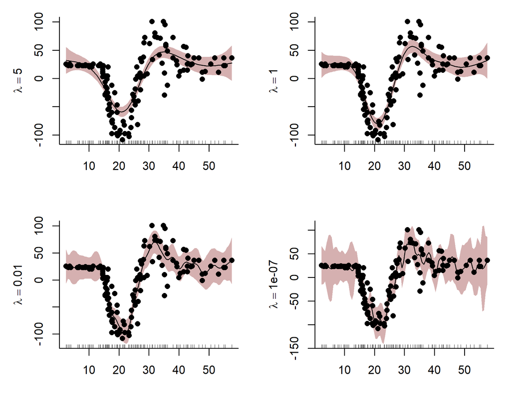

```r
data(mcycle, package = 'MASS')

m1 <- gam(accel ~ s(times, k = 50), data = mcycle, method = 'REML', sp = 5)

plot(m1, scheme = 1, residuals = TRUE, pch= 16,
     bty = 'L',
     ylab = expression(lambda == 5), xlab = '',
     shade.col = scales::alpha("#B97C7C", 0.6))

# Fit models with increasingly relaxed smooths (lambdas approaching zero)
m2 <- gam(accel ~ s(times, k = 50), data = mcycle, method = 'REML', sp = 1)
plot(m2, scheme = 1, residuals = TRUE, pch= 16,
     bty = 'L',
     ylab = expression(lambda == 1), xlab = '',
     shade.col = scales::alpha("#B97C7C", 0.6))

m3 <- gam(accel ~ s(times, k = 50), data = mcycle, method = 'REML', sp = 0.01)
plot(m3, scheme = 1, residuals = TRUE, pch= 16,
     bty = 'L',
     ylab = expression(lambda == 0.01), xlab = '',
     shade.col = scales::alpha("#B97C7C", 0.6))

m4 <- gam(accel ~ s(times, k = 50), data = mcycle, method = 'REML', sp = 0.0000001)
plot(m4, scheme = 1, residuals = TRUE, pch= 16,
     bty = 'L',
     ylab = expression(lambda == 0.0000001), xlab = '',
     shade.col = scales::alpha("#B97C7C", 0.6))
```

Notice how wiggly the function becomes in the last plot when $\lambda$ is very small, indicating that the function is overfitting to the in-sample training data. Incidentally, this behaviour mirrors what `mgcv`’s `gam.check` function will often tell you to do if you are trying to model an autocorrelated time series with a smooth function. This is because the function will need a high degree of flexibility to model both the true function and the autocorrelation

**Simulation example**

A simple simulation example is first used to demonstrate a comparison between a Dynamic GAM with a latent trend process vs a conventional GAM that includes an autoregressive observation model. First we simulate an autocorrelated trend and then draw noisy observations of that trend using a Negative Binomial observation process with overdispersion parameter = `10`

```r
#devtools::install_github("nicholasjclark/mvgam")
library(mvgam)
library(dplyr)
set.seed(1111)
trend <- cumsum(rnorm(53, -0.1, 0.5))
```

View the trend and the observation series. Here it is clear that there is autocorrelation in the trend and in the observations

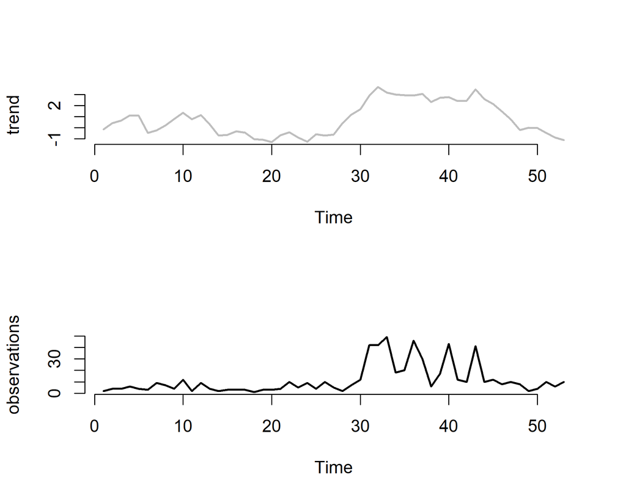

```r
layout(matrix(1:2, ncol = 1, nrow = 2))
plot(trend, type = 'l', lwd = 2, col = 'grey', bty = 'none',
     xlab = 'Time')
observations <- rnbinom(53, size = 10, mu = 4 + exp(trend))
plot(observations, type = 'l', lwd = 2, bty = 'none',
     xlab = 'Time')
```

Gather the data into a dataframe format and calculate observation lags for lag = 1, 2, and 3

```r
data.frame(y = observations) %>%
  dplyr::mutate(lag1 = lag(y),
                lag2 = lag(y, 2),
                lag3 = lag(y, 3)) %>%
  dplyr::slice_tail(n = 50) -> sim_dat
sim_dat$time <- 1:50
```

Split the data into training and testing portions and examine the objects

```r
data_train <- sim_dat[1:40,]
data_test <- sim_dat[41:50,]
head(data_train)
```

|  | y | lag1 | lag2 | lag3 | time |
| --- | --- | --- | --- | --- | --- |
| 1 | 6 | 4 | 4 | 2 | 1 |
| 2 | 4 | 6 | 4 | 4 | 2 |
| 3 | 3 | 4 | 6 | 4 | 3 |
| 4 | 9 | 3 | 4 | 6 | 4 |
| 5 | 7 | 9 | 3 | 4 | 5 |
| 6 | 4 | 7 | 9 | 3 | 6 |

```r
head(data_test)
```

|  | y | lag1 | lag2 | lag3 | time |
| --- | --- | --- | --- | --- | --- |
| 41 | 10 | 41 | 10 | 12 | 41 |
| 42 | 12 | 10 | 41 | 10 | 42 |
| 43 | 8 | 12 | 10 | 41 | 43 |
| 44 | 10 | 8 | 12 | 10 | 44 |
| 45 | 8 | 10 | 8 | 12 | 45 |
| 46 | 2 | 8 | 10 | 8 | 46 |

As a first pass at modelling this series, we will fit a GAM with parametric effects of lags 1, 2, and 3. Our primary interest is to estimate the AR parameters and the overdispersion parameter of the Negative Binomial observation process

```r
m_mgcv <- gam(y ~ lag1 + lag2 + lag3,
              data = data_train,
              method = "REML", family = nb())
```

We can view the summary of the `mgcv` model to see that the posterior estimates for the AR terms for lags 1 and 3 are strongly non-zero

```r
summary(m_mgcv)
```

```
##
## Family: Negative Binomial(2.168)
## Link function: log
##
## Formula:
## y ~ lag1 + lag2 + lag3
##
## Parametric coefficients:
##             Estimate Std. Error z value Pr(>|z|)
## (Intercept)  1.61782    0.17936   9.020  < 2e-16 ***
## lag1         0.04014    0.01060   3.787 0.000153 ***
## lag2        -0.01193    0.01257  -0.949 0.342730
## lag3         0.03083    0.01053   2.928 0.003408 **
## ---
## Signif. codes:  0 '***' 0.001 '**' 0.01 '*' 0.05 '.' 0.1 ' ' 1
##
##
## R-sq.(adj) =  0.00169   Deviance explained = 50.2%
## -REML =  142.1  Scale est. = 1         n = 40
```

Forecasting from this model requires a function to recursively update the design matrix (by filling in the values for the dynamic `lag(y)` covariates) at each successive one-step ahead prediction. Here we define a function to iteratively propagate a forecast forward according to the AR3 observation model. Note that we have used an argument to allow the lags to be fed into the model on the log scale, this will make more sense in a moment as we inspect the forecasts of the model

**Click for definition of `recurse_ar3`**

```r
recurse_ar3 = function(model, coef_sim, lagged_vals, h, log_lags = F){
  # Initiate state vector
  states <- rep(NA, length = h + 3)
  # Last three values of the conditional expectations begin the state vector
  if(log_lags){
    states[1] <- exp(as.numeric(lagged_vals[3]))
    states[2] <- exp(as.numeric(lagged_vals[2]))
    states[3] <- exp(as.numeric(lagged_vals[1]))
  } else {
    states[1] <- as.numeric(lagged_vals[3])
    states[2] <- as.numeric(lagged_vals[2])
    states[3] <- as.numeric(lagged_vals[1])
  }

  # Get a random sample of the smooth coefficient uncertainty matrix
  # to use for the entire forecast horizon of this particular path
  gam_coef_index <- sample(seq(1, NROW(coef_sim)), size = 1)
  # For each following timestep, recursively predict based on the
  # predictions at each previous lag
  for (t in 4:(h + 3)) {
    newdata <- data_test[t-3, ]
    if(log_lags){
      newdata$lag1 <- log(states[t-1] + 0.01)
      newdata$lag2 <- log(states[t-2] + 0.01)
      newdata$lag3 <- log(states[t-3] + 0.01)
    } else {
      newdata$lag1 <- states[t-1]
      newdata$lag2 <- states[t-2]
      newdata$lag3 <- states[t-3]
    }

    colnames(newdata) <- colnames(data_test)
    Xp <- predict(model, newdata = newdata, type = 'lpmatrix')
    # Calculate the posterior prediction for this timepoint; use an upper constraint
    # to ensure the values don't blow up to infinity
    mu <- rnbinom(1, mu = min(100000, exp(Xp %*% coef_sim[gam_coef_index,])),
                  size = model$family$getTheta(TRUE))
    # Fill in the state vector and iterate to the next timepoint
    states[t] <- mu
  }
  # Return the forecast path
  states[-c(1:3)]
}
```

Draw 1000 parameter estimates from the GAM posterior and use these to propagate the forecast for 10 timesteps ahead

```r
coef_sim <- MASS::mvrnorm(1000, mu = m_mgcv$coefficients, Sigma = m_mgcv$Vp)
gam_sims <- matrix(NA, nrow = 1000, ncol = 10)
for(i in 1:1000){
  gam_sims[i,] <- recurse_ar3(m_mgcv,
                              coef_sim,
                              lagged_vals = c(data_test$lag1[1],
                                              data_test$lag2[1],
                                              data_test$lag3[1]),
                              h = 10)
}
```

```r
m_mvgam <- mvgam(formula = y ~ 1,
                 data = data_train,
                 newdata = data_test,
                 family = 'nb',
                 trend_model = 'AR3',
                 chains = 4,
                 burnin = 1000)
```

[output not shown]

[output cut: 23 more lines]

[output not shown]

You can view the summary of the resulting model using the `summary.mvgam S3` function, which gives an overview of convergence and effective sample size diagnostics for the model’s parameters

```r
summary(m_mvgam)
```

```
## GAM formula:
```

```
## y ~ 1
```

```
## Family:
```

```
## negative binomial
```

```
## Link function:
```

```
## log
```

```
## Trend model:
```

```
## AR3
```

```
## N series:
```

```
## 1
```

```
## N observations:
```

```
## 40
```

```
## Status:
```

```
## Fitted using Stan
```

```
## Dispersion parameter estimates:
```

```
##           2.5%      50%    97.5% Rhat n.eff
## phi[1] 3.55125 12.61605 307.9474 1.01   375
```

```
## GAM coefficient (beta) estimates:
```

```
##               2.5%     50%    97.5% Rhat n.eff
## (Intercept) 1.9066 2.38406 2.839683 1.02   234
```

```
## Latent trend parameter estimates:
```

```
##                2.5%         50%     97.5% Rhat n.eff
## ar1[1]    0.1938083  0.67732050 1.2453535 1.01   361
## ar2[1]   -0.7512094 -0.09949965 0.6265418 1.01   301
## ar3[1]   -0.3051493  0.30263050 0.7515455 1.01   383
## sigma[1]  0.3097466  0.55525100 0.8220678 1.01   224
```

```
## Stan MCMC diagnostics
```

```
## n_eff / iter looks reasonable for all parameters
## Rhat looks reasonable for all parameters
## 0 of 2000 iterations ended with a divergence (0%)
## 0 of 2000 iterations saturated the maximum tree depth of 12 (0%)
## E-FMI indicated no pathological behavior
```

The model file can also be viewed, which can be handy for making modifications to the model so that extra stochastic elements can be added to a user’s bespoke model. Notice how the summary at the top of the model file describes the data elements (and their dimensions) that are needed to condition the model, again the hope is that this simplifies the task of modifying the model for any additional user-specific requirements

```r
m_mvgam$model_file
```

```
##   [1] ""
##   [2] "// Stan model code generated by package mvgam"
##   [3] "functions {"
##   [4] "vector rep_each(vector x, int K) {"
##   [5] "int N = rows(x);"
##   [6] "vector[N * K] y;"
##   [7] "int pos = 1;"
##   [8] "for (n in 1:N) {"
##   [9] "for (k in 1:K) {"
##  [10] "y[pos] = x[n];"
##  [11] "pos += 1;"
##  [12] "}"
##  [13] "}"
##  [14] "return y;"
##  [15] "}"
```

[output cut: 109 more lines]

Users can also view the data and initial values that `mvgam` uses to condition the model by either setting the argument `return_model_data = TRUE` or by setting `run_model = FALSE`. The latter is faster for simply generating the necessary objects and initial value functions. These options will also return the `pregam` structure that is necessary to convert `MCMC` samples into an object that can be readily used by `mgcv` to generate predictions and calculate important quantities such as effective degrees of freedom (see `help(jagam)` for more details)

```r
mod_skeleton <- mvgam(y ~ 1,
                 data = data_train,
                 newdata = data_test,
                 family = 'nb',
                 trend_model = 'AR3',
                 chains = 4,
                 burnin = 1000,
                 run_model = FALSE)
str(mod_skeleton$model_data)
```

```
## List of 15
##  $ y           : num [1:50, 1] 6 4 3 9 7 4 12 2 9 4 ...
##  $ n           : int 50
##  $ X           : num [1:50, 1] 1 1 1 1 1 1 1 1 1 1 ...
##   ..- attr(*, "dimnames")=List of 2
##   .. ..$ : chr [1:50] "X" "X.1" "X.2" "X.3" ...
##   .. ..$ : chr "X.Intercept."
##  $ p_coefs     : num [1(1d)] 2.57
##  $ p_taus      : num [1(1d)] 10.8
##  $ ytimes      : int [1:50, 1] 1 2 3 4 5 6 7 8 9 10 ...
##  $ n_series    : int 1
##  $ min_eps     : num 2.22e-16
##  $ y_observed  : num [1:50, 1] 1 1 1 1 1 1 1 1 1 1 ...
##  $ total_obs   : int 50
##  $ num_basis   : int 1
##  $ n_nonmissing: int 40
##  $ obs_ind     : int [1:40] 1 2 3 4 5 6 7 8 9 10 ...
##  $ flat_ys     : num [1:40] 6 4 3 9 7 4 12 2 9 4 ...
##  $ flat_xs     : num [1:40, 1] 1 1 1 1 1 1 1 1 1 1 ...
##   ..- attr(*, "dimnames")=List of 2
##   .. ..$ : chr [1:40] "X" "X.1" "X.2" "X.3" ...
##   .. ..$ : NULL
```

```r
mod_skeleton$inits
```

```
## function() {
##           list(b_raw = runif(model_data$num_basis, -2, 2),
##                phi_inv = runif(NCOL(model_data$ytimes), 1, 50),
##                sigma = runif(model_data$n_series, 0.075, 1))
##         }
## <bytecode: 0x000002cd8cd803e0>
## <environment: 0x000002cd86d03850>
```

```r
head(mod_skeleton$pregam)
```

```
## $m
## [1] 1
##
## $min.sp
## NULL
##
## $pearson.extra
## [1] 0
##
## $dev.extra
## [1] 0
##
## $n.true
## [1] -1
##
## $pterms
## y ~ 1
## attr(,"variables")
## list(y)
## attr(,"factors")
## integer(0)
## attr(,"term.labels")
## character(0)
## attr(,"order")
## integer(0)
## attr(,"intercept")
## [1] 1
## attr(,"response")
## [1] 1
## attr(,".Environment")
## <environment: R_GlobalEnv>
## attr(,"predvars")
## list(y)
## attr(,"dataClasses")
##         y
## "numeric"
```

The same steps above can be used to generate `Stan` data and modelling files:

```r
mod_skeleton <- mvgam(y ~ 1,
                 data = data_train,
                 newdata = data_test,
                 family = 'nb',
                 trend_model = 'AR3',
                 chains = 4,
                 use_stan = TRUE,
                 run_model = FALSE)
str(mod_skeleton$model_data)
```

```
## List of 15
##  $ y           : num [1:50, 1] 6 4 3 9 7 4 12 2 9 4 ...
##  $ n           : int 50
##  $ X           : num [1:50, 1] 1 1 1 1 1 1 1 1 1 1 ...
##   ..- attr(*, "dimnames")=List of 2
##   .. ..$ : chr [1:50] "X" "X.1" "X.2" "X.3" ...
##   .. ..$ : chr "X.Intercept."
##  $ p_coefs     : num [1(1d)] 2.57
##  $ p_taus      : num [1(1d)] 11
##  $ ytimes      : int [1:50, 1] 1 2 3 4 5 6 7 8 9 10 ...
##  $ n_series    : int 1
##  $ min_eps     : num 2.22e-16
##  $ y_observed  : num [1:50, 1] 1 1 1 1 1 1 1 1 1 1 ...
##  $ total_obs   : int 50
##  $ num_basis   : int 1
##  $ n_nonmissing: int 40
##  $ obs_ind     : int [1:40] 1 2 3 4 5 6 7 8 9 10 ...
##  $ flat_ys     : num [1:40] 6 4 3 9 7 4 12 2 9 4 ...
##  $ flat_xs     : num [1:40, 1] 1 1 1 1 1 1 1 1 1 1 ...
##   ..- attr(*, "dimnames")=List of 2
##   .. ..$ : chr [1:40] "X" "X.1" "X.2" "X.3" ...
##   .. ..$ : NULL
```

```r
mod_skeleton$inits
```

```
## function() {
##           list(b_raw = runif(model_data$num_basis, -2, 2),
##                phi_inv = runif(NCOL(model_data$ytimes), 1, 50),
##                sigma = runif(model_data$n_series, 0.075, 1))
##         }
## <bytecode: 0x000002cd8cd803e0>
## <environment: 0x000002cd8aca8b10>
```

```r
head(mod_skeleton$pregam)
```

```
## $m
## [1] 1
##
## $min.sp
## NULL
##
## $pearson.extra
## [1] 0
##
## $dev.extra
## [1] 0
##
## $n.true
## [1] -1
##
## $pterms
## y ~ 1
## attr(,"variables")
## list(y)
## attr(,"factors")
## integer(0)
## attr(,"term.labels")
## character(0)
## attr(,"order")
## integer(0)
## attr(,"intercept")
## [1] 1
## attr(,"response")
## [1] 1
## attr(,".Environment")
## <environment: R_GlobalEnv>
## attr(,"predvars")
## list(y)
## attr(,"dataClasses")
##         y
## "numeric"
```

The `Stan` model file is also designed to be as descriptive as possible about the data objects that are required to condition the model

````r
cat(c("```stan", mod_skeleton$model_file, "```"), sep = "\n")
````

```stan
// Stan model code generated by package mvgam
functions {
vector rep_each(vector x, int K) {
int N = rows(x);
vector[N * K] y;
int pos = 1;
for (n in 1:N) {
for (k in 1:K) {
y[pos] = x[n];
pos += 1;
}
}
return y;
}
}
data {
int<lower=0> total_obs; // total number of observations
int<lower=0> n; // number of timepoints per series
int<lower=0> n_series; // number of series
int<lower=0> num_basis; // total number of basis coefficients
real p_taus[1]; // prior precisions for parametric coefficients
real p_coefs[1]; // prior locations for parametric coefficients
matrix[total_obs, num_basis] X; // mgcv GAM design matrix
int<lower=0> ytimes[n, n_series]; // time-ordered matrix (which col in X belongs to each [time, series] observation?)

int<lower=0> n_nonmissing; // number of nonmissing observations
int<lower=0> flat_ys[n_nonmissing]; // flattened nonmissing observations
matrix[n_nonmissing, num_basis] flat_xs; // X values for nonmissing observations
int<lower=0> obs_ind[n_nonmissing]; // indices of nonmissing observations
}
parameters {
// raw basis coefficients
vector[num_basis] b_raw;

// negative binomial overdispersion
vector<lower=0>[n_series] phi_inv;

// latent trend AR1 terms
vector<lower=-1.5,upper=1.5>[n_series] ar1;

// latent trend AR2 terms
vector<lower=-1.5,upper=1.5>[n_series] ar2;

// latent trend AR3 terms
vector<lower=-1.5,upper=1.5>[n_series] ar3;

// latent trend variance parameters
vector<lower=0>[n_series] sigma;

// latent trends
matrix[n, n_series] trend;

}

transformed parameters {
// basis coefficients
vector[num_basis] b;

b[1:num_basis] = b_raw[1:num_basis];

}

model {
for (i in 1:1) {
b_raw[i] ~ normal(p_coefs[i], sqrt(1 / p_taus[i]));
}

// priors for AR parameters
ar1 ~ std_normal();
ar2 ~ std_normal();
ar3 ~ std_normal();

// priors for overdispersion parameters
phi_inv ~ student_t(3, 0, 0.1);

// priors for latent trend variance parameters
sigma ~ exponential(2);

// trend estimates
trend[1, 1:n_series] ~ normal(0, sigma);
trend[2, 1:n_series] ~ normal(trend[1, 1:n_series] * ar1, sigma);
trend[3, 1:n_series] ~ normal(trend[2, 1:n_series] * ar1 + trend[1, 1:n_series] * ar2, sigma);
for(s in 1:n_series){
trend[4:n, s] ~ normal(ar1[s] * trend[3:(n - 1), s] + ar2[s] * trend[2:(n - 2), s] + ar3[s] * trend[1:(n - 3), s], sigma[s]);
}

{
// likelihood functions
vector[n_nonmissing] flat_trends;
real flat_phis[n_nonmissing];
flat_trends = (to_vector(trend))[obs_ind];
flat_phis = to_array_1d(rep_each(phi_inv, n)[obs_ind]);
flat_ys ~ neg_binomial_2(
exp(append_col(flat_xs, flat_trends) * append_row(b, 1.0)),
inv(flat_phis));
}
}


generated quantities {
vector[total_obs] eta;
matrix[n, n_series] mus;
vector[n_series] tau;
array[n, n_series] int ypred;
matrix[n, n_series] phi_vec;
vector[n_series] phi;
phi = inv(phi_inv);
for (s in 1:n_series) {
phi_vec[1:n,s] = rep_vector(phi[s], n);
}

for (s in 1:n_series) {
tau[s] = pow(sigma[s], -2.0);
}

// posterior predictions
eta = X * b;
for(s in 1:n_series){
mus[1:n, s] = eta[ytimes[1:n, s]] + trend[1:n, s];
ypred[1:n, s] = neg_binomial_2_rng(exp(mus[1:n, s]), phi_vec[1:n, s]);
}
}
```

Now we will evaluate the forecasts for each of the models. Here we define a function to plot posterior empirical forecast quantiles and calculate the Discrete Rank Probability Score (DRPS, a proper scoring rule for evaluating probabilistic forecast distributions) for each of the out of sample forecasts. The final score for each forecast is the sum of DRPS values at each forecast horizon, with the lower score being the favoured forecast. The function returns a plot of the forecast distribution and also prints the DRPS score

**Click for definition of `plot_fc_horizon`**

```r
plot_fc_horizon = function(gam_sims, main){
  probs = c(0.05, 0.2, 0.3, 0.4, 0.5, 0.6, 0.7, 0.8, 0.95)
  cred <- sapply(1:NCOL(gam_sims),
                 function(n) quantile(gam_sims[,n],
                                      probs = probs))

  c_light <- c("#DCBCBC")
  c_light_highlight <- c("#C79999")
  c_mid <- c("#B97C7C")
  c_mid_highlight <- c("#A25050")
  c_dark <- c("#8F2727")
  c_dark_highlight <- c("#7C0000")

  ylim <- range(c(0, data_test$y[1:NCOL(cred)] * 1.25,
                  cred * 1.25))
  pred_vals <- 1:NCOL(cred)
  plot(1, xlim = c(1, NCOL(cred)),
       bty = 'L',
       col = rgb(1,0,0, alpha = 0),
       ylim = ylim,
       ylab = 'Predicted counts',
       xlab = 'Forecast horizon',
       main = main)

  polygon(c(pred_vals, rev(pred_vals)), c(cred[1,], rev(cred[9,])),
          col = c_light, border = NA)
  polygon(c(pred_vals, rev(pred_vals)), c(cred[2,], rev(cred[8,])),
          col = c_light_highlight, border = NA)
  polygon(c(pred_vals, rev(pred_vals)), c(cred[3,], rev(cred[7,])),
          col = c_mid, border = NA)
  polygon(c(pred_vals, rev(pred_vals)), c(cred[4,], rev(cred[6,])),
          col = c_mid_highlight, border = NA)
  lines(pred_vals, cred[5,], col = c_dark, lwd = 2.5)
  points(data_test$y[1:NCOL(cred)], pch = 16, cex = .65, col = 'white')
  points(data_test$y[1:NCOL(cred)], pch = 16, cex = .55)
  box(bty = 'L', lwd = 2)

  # Calculate out of sample DRPS and print the score
  drps_score <- function(truth, fc, interval_width = 0.9){
    nsum <- 1000
    Fy = ecdf(fc)
    ysum <- 0:nsum
    indicator <- ifelse(ysum - truth >= 0, 1, 0)
    score <- sum((indicator - Fy(ysum))^2)

    # Is value within empirical interval?
    interval <- quantile(fc, probs = c((1-interval_width)/2,
                                       (interval_width + (1-interval_width)/2)))
    in_interval <- ifelse(truth <= interval[2] & truth >= interval[1], 1, 0)
    return(c(score, in_interval))
  }

  # Wrapper to operate on all observations in fc_horizon
  drps_mcmc_object <- function(truth, fc, interval_width = 0.9){
    indices_keep <- which(!is.na(truth))
    if(length(indices_keep) == 0){
      scores = data.frame('drps' = rep(NA, length(truth)),
                          'interval' = rep(NA, length(truth)))
    } else {
      scores <- matrix(NA, nrow = length(truth), ncol = 2)
      for(i in indices_keep){
        scores[i,] <- drps_score(truth = as.vector(truth)[i],
                                 fc = fc[,i], interval_width)
      }
    }
    scores
  }

  truth <- data_test$y[1:NCOL(cred)]
  fc <- gam_sims

  message('Out of sample DRPS:')
  print(sum(drps_mcmc_object(as.vector(truth),
                             fc)[,1]))
  message()

}
```

Evaluate forecasts for the two models; first the `mgcv` autoregressive observation model

```
## Out of sample DRPS:
```

```
## [1] 649.8801
```

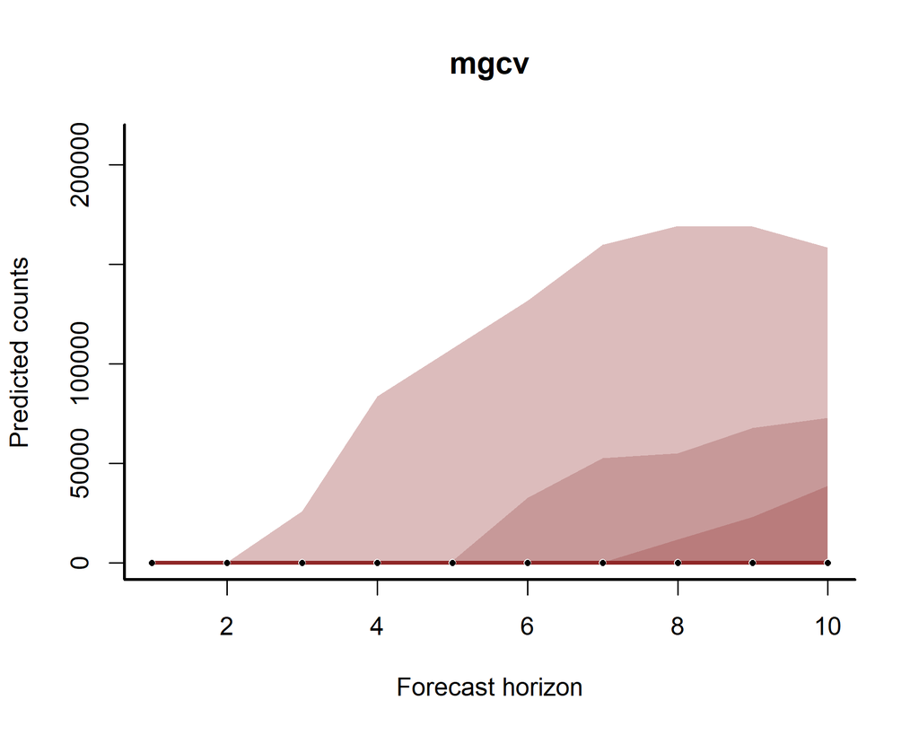

```r
plot_fc_horizon(gam_sims = gam_sims[,1:10], main = 'mgcv')
```

And now the `mvgam` latent trend model

```
## Out of sample DRPS:
```

```
## [1] 79.05349
```

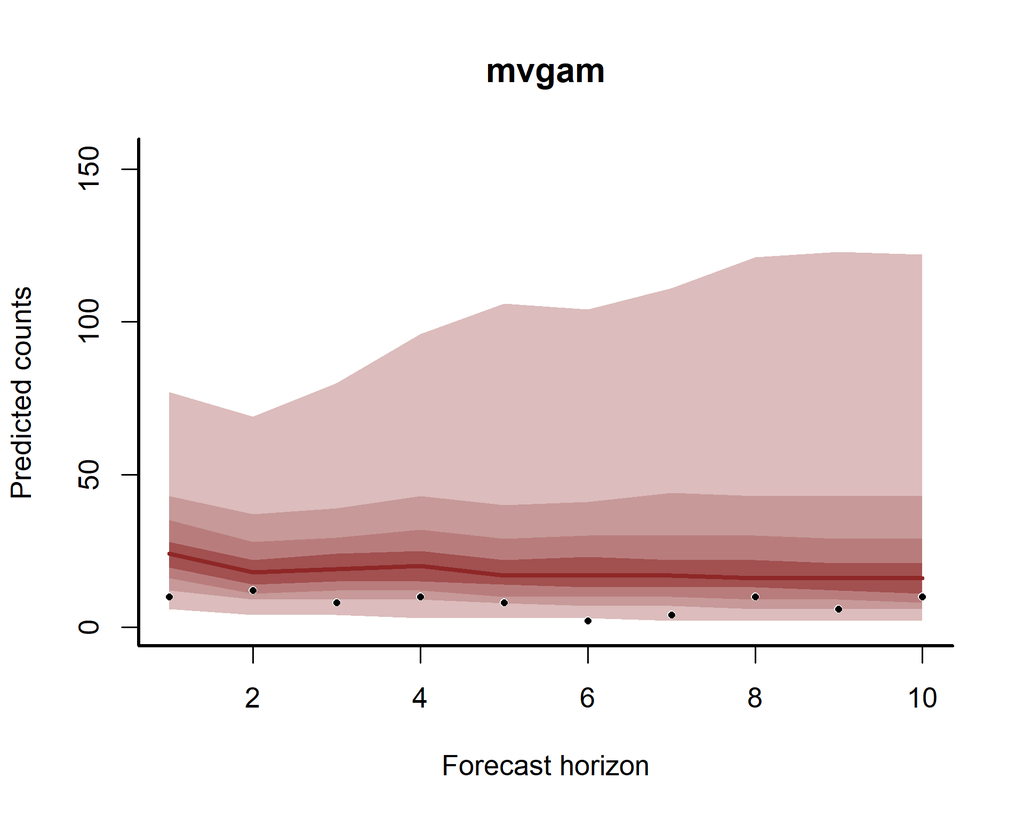

```r
plot_fc_horizon(gam_sims = MCMCvis::MCMCchains(m_mvgam$model_output,
                                               'ypred')[,(NROW(m_mvgam$obs_data)+1):
                                                          (NROW(m_mvgam$obs_data)+10)],
                main = 'mvgam')
```

Generally the uncertainy blows out when forecasting further ahead for the `mgcv` model (why might this be?); if we only look 2 timesteps ahead, it is not quite as terrible but it becomes more clear what is happening

```
## Out of sample DRPS:
```

```
## [1] 18.44607
```

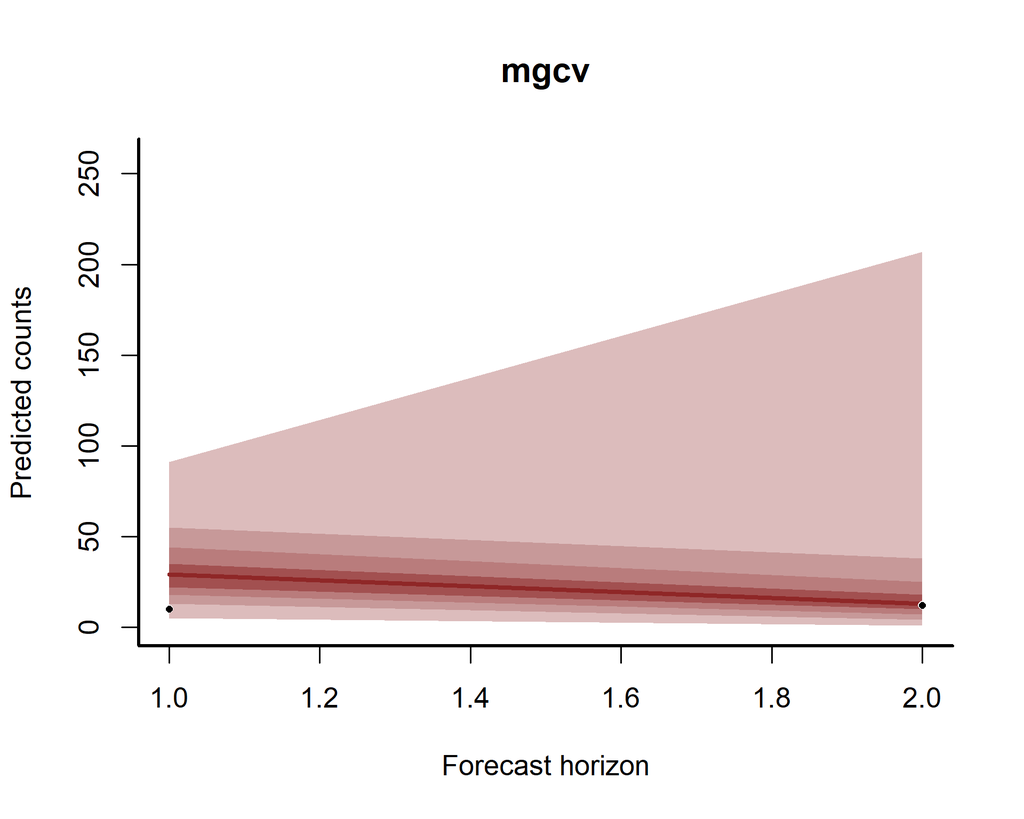

```r
plot_fc_horizon(gam_sims = gam_sims[,1:2], main = 'mgcv')
```

```
## Out of sample DRPS:
```

```
## [1] 14.05655
```

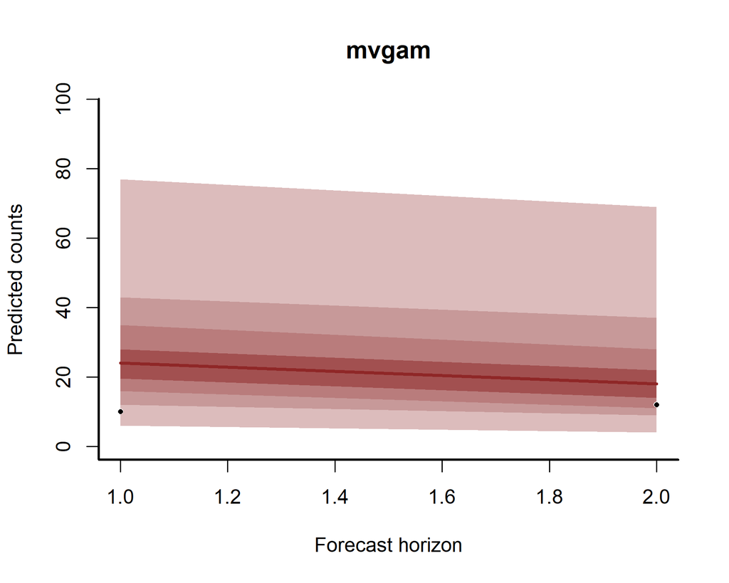

```r
plot_fc_horizon(gam_sims = MCMCvis::MCMCchains(m_mvgam$model_output,
                                               'ypred')[,(NROW(m_mvgam$obs_data)+1):
                                                          (NROW(m_mvgam$obs_data)+2)],
                main = 'mvgam')
```

Why does autocorrelated observation model perform so badly? Q-Q plots give some insight, as they clearly indicate the dynamic latent trend model shows a better fit of the observation process to the data compared to the autocorrelated observation model

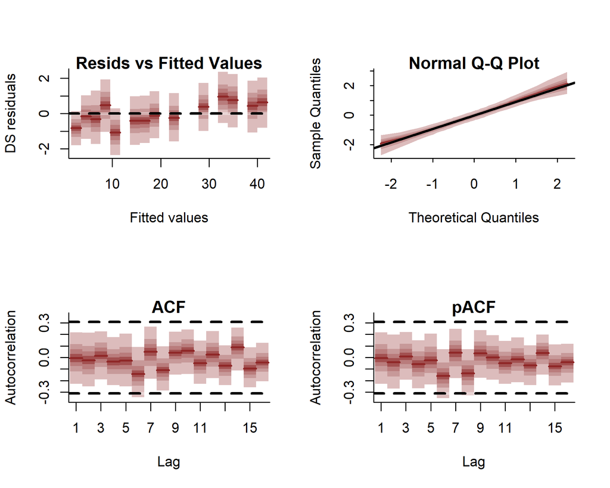

```r
plot(m_mvgam, 'residuals')
```

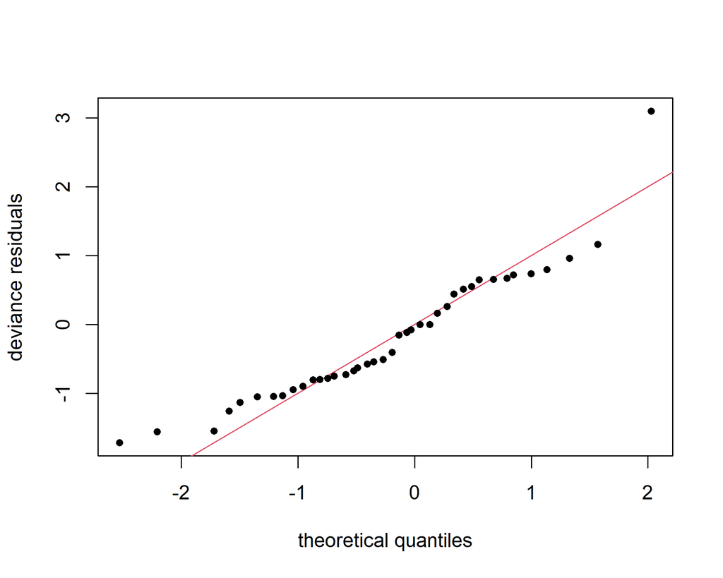

```r
qq.gam(m_mgcv, pch = 16, lwd = 3, cex = 0.8)
```

In fact the the autocorrelated observation model is overestimating the amount of overdispersion in the data. This can partially explain the exponentially growing uncertainties in the mgcv forecast The truth for the ovderdispersion parameter is `10`. This is likely driven by the autoregressive model’s high sensitivity to the noisy observation process. Observations in ecology very often display properties of overdispersion, and this results in observation ‘outliers’ that can have large leverage on resulting parameter estimates for autoregressive models. The noisy observation process is not a problem for latent trend models such as those estimated by `mvgam`, as the observation model is estimated separately from the temporal process (as is the norm for state-space models)

```r
m_mgcv$family$getTheta(TRUE)
```

```
## [1] 2.167732
```

```r
quantile(MCMCvis::MCMCchains(m_mvgam$model_output, 'phi'), c(0.1, 0.5, 0.9))
```

```
##      10%      50%      90%
##  4.98820 12.61605 70.76188
```

Looking at estimates for the full trend and forecast distributions shows how the `mvgam` model is clearly doing a decent job of tracking the latent state up to the end of the training period while also giving reasonable estimates for the overdispersion in the data

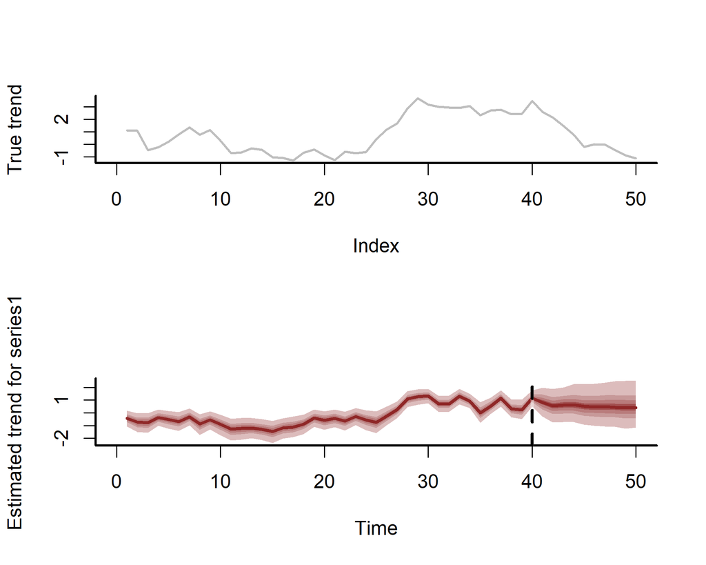

```r
layout(matrix(1:2, ncol = 1, nrow = 2))
plot(trend[4:53], xlim = c(0, 50), bty = 'L', type = 'l', lwd = 2, col = 'grey',
     ylab = 'True trend')
box(bty = 'L', lwd = 2)
plot(m_mvgam, 'trend', newdata = data_test)
```

```r
layout(1)
```

```
## Out of sample DRPS:
```

```
## [1] 79.05349
```

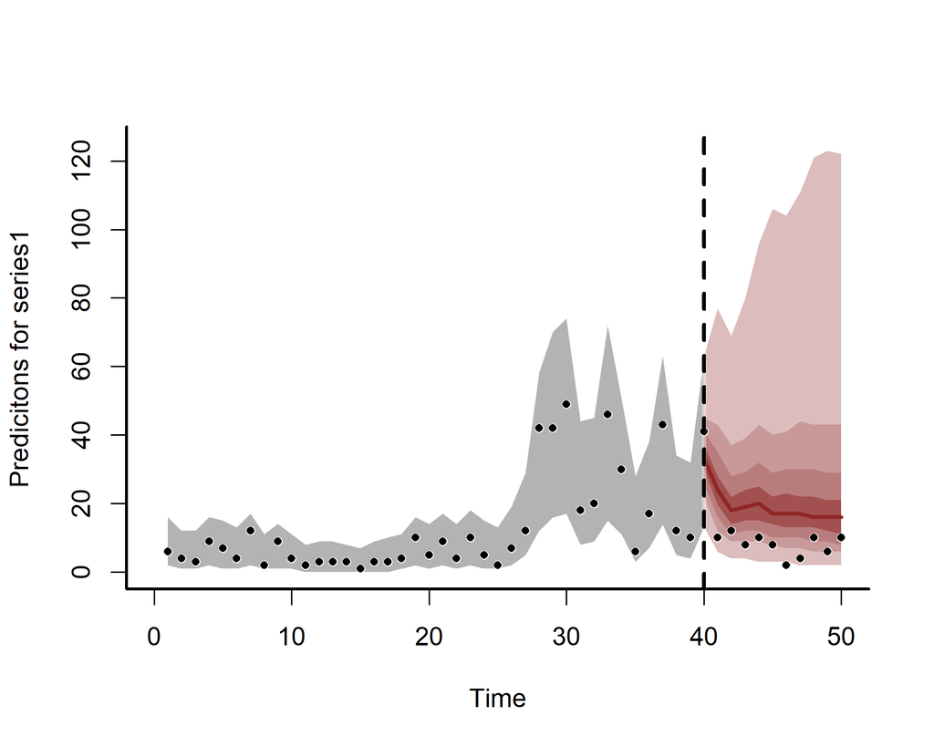

```r
plot(m_mvgam, 'forecast', newdata = data_test)
```

We can get a better idea of what is happening for the autoregressive observation model by plotting posterior realisations on the log scale. Here each line is a realisation, and we show these lines as a spaghetti plot to make it easier to visualise the diversity of possible forecast paths that are compatible with our model configuration.

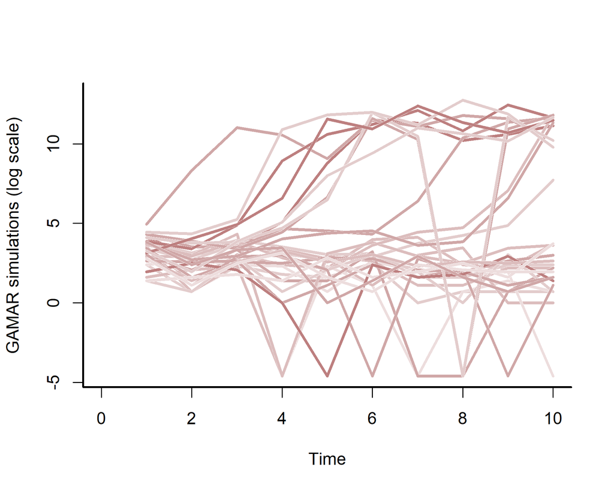

```r
plot(1, type = "n", bty = 'L',
     xlab = 'Time',
     ylab = 'GAMAR simulations (log scale)',
     xlim = c(0, NCOL(gam_sims)),
     ylim = range(log(gam_sims + 0.01)))
for(i in 1:30){
  lines(x = 1:NCOL(gam_sims),
        y = log(gam_sims[i,] + 0.01),
        col = 'white',
        lwd = 3)
  lines(x = 1:NCOL(gam_sims),
        y = log(gam_sims[i,] + 0.01),
        col = sample(c("#DCBCBC80",
                       "#C7999980",
                       "#B97C7C80",
                       "#A2505080",
                       "#7C000080"), 1),
        lwd = 2.75)
}
box(bty = 'L', lwd = 2)
```

`mvgam` offers options to plot realisations for most types of plots as well. Repeating the trend plot above (which automatically shows the expected latent trend on the log scale) shows that the dynamic GAM does not suffer from the same explosion towards infinity that the autoregressive model suffers from

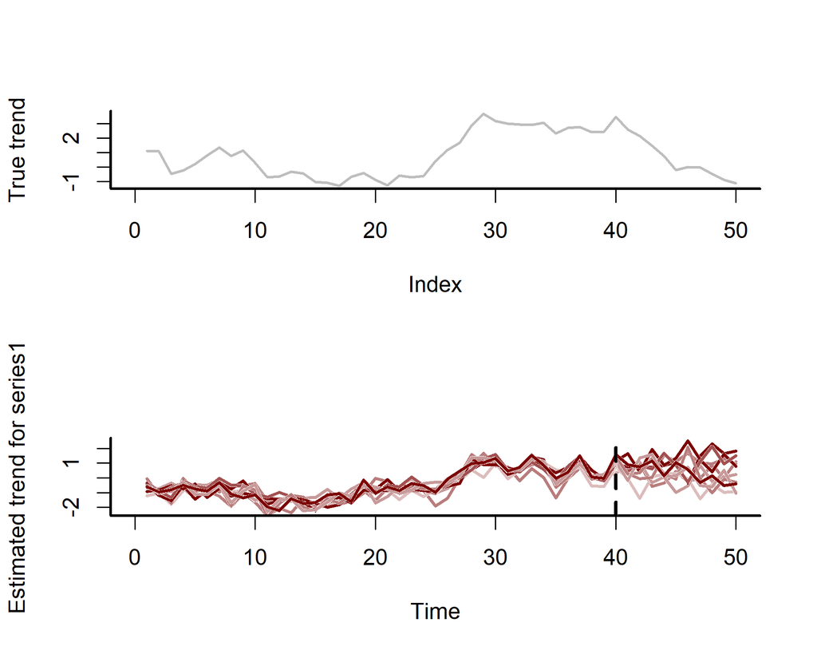

```r
layout(matrix(1:2, ncol = 1, nrow = 2))
plot(trend[4:53], xlim = c(0, 50), type = 'l', lwd = 2, col = 'grey',
     ylab = 'True trend', bty = 'L')
box(bty = 'L', lwd = 2)
plot(m_mvgam, 'trend', newdata = data_test, realisations = TRUE,
     n_realisations = 10)
```

```r
layout(1)
```

From the plots above it is apparent that although some of the realisations are sensible, as soon as a path climbs upward it tends to skyrocket up towards infinity. It is sensible then to conclude that an autocorrelated observation model will be extremely sensitive to the measurement process (particularly when there is overdispersion, outliers or missing observations), which is not a problem for the latent temporal process model. With this information in mind, could we improve the autocorrelated observation model by using logs of lagged observations, rather than raw lagged observations?

```r
data.frame(y = observations) %>%
  dplyr::mutate(lag1 = log(lag(y) + 0.01),
                lag2 = log(lag(y, 2) + 0.01),
                lag3 = log(lag(y, 3) + 0.01)) %>%
  dplyr::mutate(cov1 = rnorm(53)) %>%
  dplyr::slice_tail(n = 50) -> sim_dat
sim_dat$time <- 1:50
data_train <- sim_dat[1:40,]
data_test <- sim_dat[41:50,]
m_mgcv <- gam(y ~ lag1 + lag2 + lag3,
              data = data_train,
              method = "REML", family = nb())
```

Compute the forecasts but use logged lags instead of raw lags

```r
coef_sim <- MASS::mvrnorm(1000, mu = m_mgcv$coefficients, Sigma = m_mgcv$Vp)
gam_sims <- matrix(NA, nrow = 1000, ncol = 10)
for(i in 1:1000){
  gam_sims[i,] <- recurse_ar3(m_mgcv,
                              coef_sim,
                              lagged_vals = c(data_test$lag1[1],
                                              data_test$lag2[1],
                                              data_test$lag3[1]),
                              log_lags = TRUE,
                              h = 10)
}
```

Evaluate the log-AR model against the dynamic GAM

```
## Out of sample DRPS:
```

```
## [1] 105.754
```

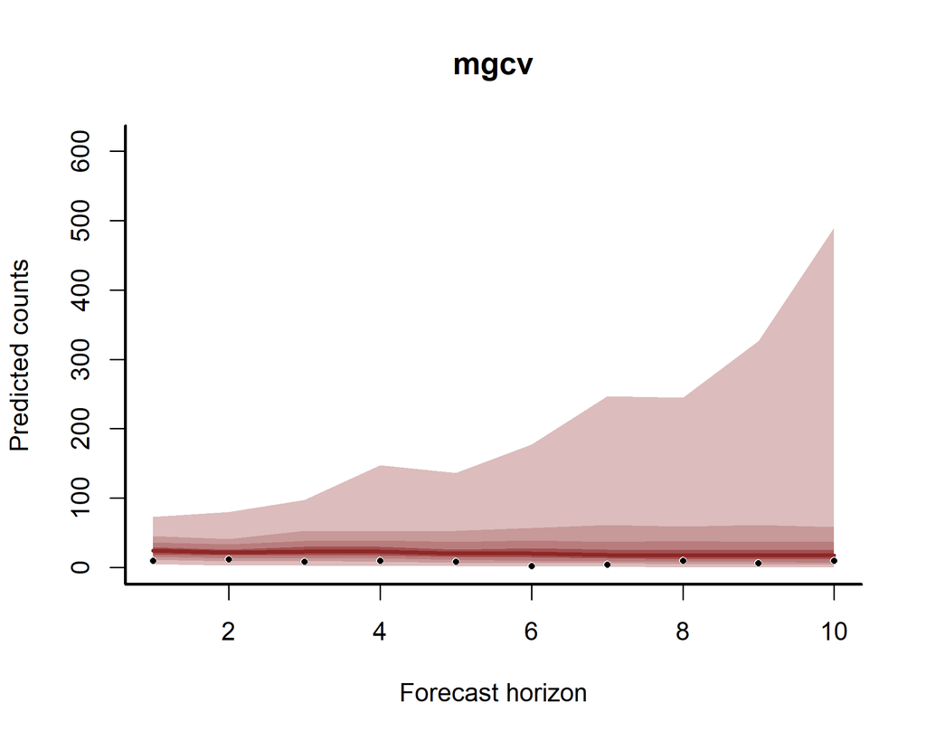

```r
plot_fc_horizon(gam_sims = gam_sims[,1:10], main = 'mgcv')
```

```
## Out of sample DRPS:
```

```
## [1] 79.05349
```

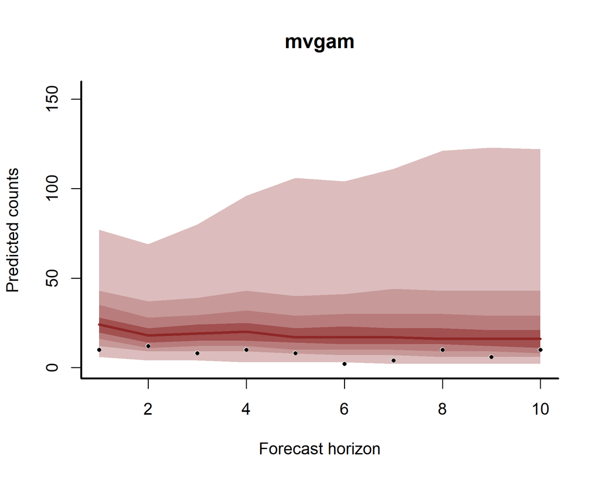

```r
plot_fc_horizon(gam_sims = MCMCvis::MCMCchains(m_mvgam$model_output,
                                               'ypred')[,(NROW(m_mvgam$obs_data)+1):
                                                          (NROW(m_mvgam$obs_data)+10)],
                main = 'mvgam')
```

We should also re-check the autoregressive model’s realisations, which look much better now

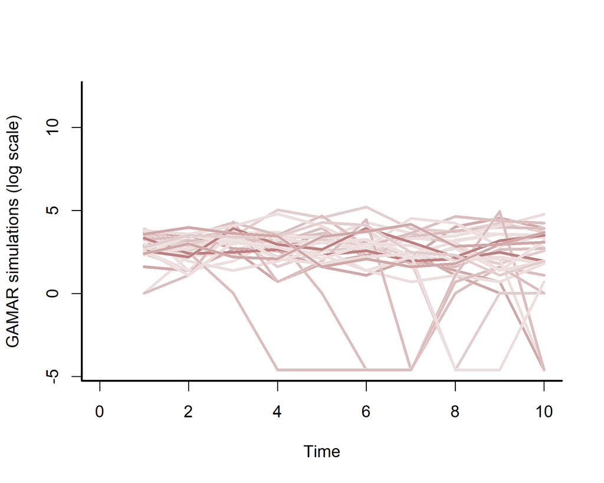

```r
plot(1, type = "n", bty = 'L',
     xlab = 'Time',
     ylab = 'GAMAR simulations (log scale)',
     xlim = c(0, NCOL(gam_sims)),
     ylim = range(log(gam_sims + 0.01)))
for(i in 1:30){
  lines(x = 1:NCOL(gam_sims),
        y = log(gam_sims[i,] + 0.01),
        col = 'white',
        lwd = 3)
  lines(x = 1:NCOL(gam_sims),
        y = log(gam_sims[i,] + 0.01),
        col = sample(c("#DCBCBC80",
                       "#C7999980",
                       "#B97C7C80",
                       "#A2505080",
                       "#7C000080"), 1),
        lwd = 2.75)
}
box(bty = 'L', lwd = 2)
```

This version (with logged lags) performs much better than the raw lag version, with sensible forecasts that are not blowing up to infinity. In fact, this forecast is now more comparable to the dynamic GAM where the latent temporal process is estimated separately from the observation process, at least for this particular simulation. There are of course many other advantages to the state-space representation that is used by `mvgam`, including:

1. It is far easier to handle missing values (which will result in loss of many observations when fitting `mgcv` models, especially at higher order lags, due to missing outcomes AND missing predictors) and measurement error
2. Latent trend processes provide recursive expressions for h-step ahead prediction and historical filtering
3. Irregularly sampled observational time series can be readily modeled as the latent temporal process can simply be ‘forecasted’ over the missing observations
4. Multiple observation processes can depend on shared latent states

**Fisheries landings example**

Now for an empirical example of DGAMs, using historical data on US fisheries landings made available by a recent paper published in `Methods in Ecology and Evolution` ([Smoothed dynamic factor analysis for identifying trends in multivariate time series; Ward et al 2021](https://besjournals.onlinelibrary.wiley.com/doi/abs/10.1111/2041-210X.13788)). The data consists of adjusted landings for 13 species or groups reported annually from multiple fisheries over a 39-year period (1981–2019)

```r
data <- read.csv('https://raw.githubusercontent.com/fate-ewi/gpdfa/main/data/port_landings_table2.csv')
head(data)
```

First some data wrangling to clean the column names, create logged lags for the species of interest (the Ling cod) and gather values for an additional species that will be used as a (potentially nonlinear) covariate (the whiting). These two species were chosen in an ad-hoc fashion based on results of the above paper, which found that they demonstrated somewhat opposing patterns in their historical trends. Note that this is not meant to be a full in-depth analysis of these data, but rather a simple example to demonstrate how `mvgam` can be used for empirical series.

```r
data %>%
  janitor::clean_names() %>%
  dplyr::mutate(y = lingcod) %>%
  dplyr::mutate(lag1 = log(lag(y) + 0.01),
                lag2 = log(lag(y, 2) + 0.01),
                lag3 = log(lag(y, 3) + 0.01)) %>%
  dplyr::select(y,
                lag1,
                lag2,
                lag3,
                p_whiting) %>%
  # The nonlinear covariate will be a smooth of standardised whiting landings
  dplyr::mutate(p_whiting = as.vector(scale(p_whiting))) %>%
  dplyr::slice_tail(n = 36) -> model_dat
model_dat$time <- 1:NROW(model_dat)
```

View the modelling dataframe and check for any `NAs` (which will be omitted by `mgcv` automatically)

```r
head(model_dat)
```

|  | y | lag1 | lag2 | lag3 | p_whiting | time |
| --- | --- | --- | --- | --- | --- | --- |
| 1 | 4029 | 8.355147 | 8.253230 | 8.102589 | -1.378056 | 1 |
| 2 | 3839 | 8.301276 | 8.355147 | 8.253230 | -1.351442 | 2 |
| 3 | 1891 | 8.252970 | 8.301276 | 8.355147 | -1.361176 | 3 |
| 4 | 2587 | 7.544866 | 8.252970 | 8.301276 | -1.331000 | 4 |
| 5 | 2767 | 7.858258 | 7.544866 | 8.252970 | -1.283989 | 5 |
| 6 | 3563 | 7.925523 | 7.858258 | 7.544866 | -1.271578 | 6 |

```r
anyNA(model_dat)
```

```
## [1] FALSE
```

Plot the time series for the species of interest (the ling cod)

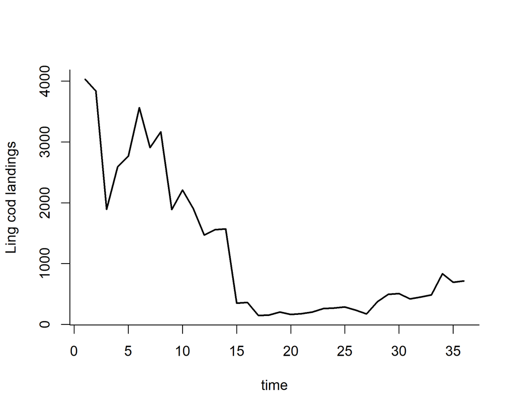

```r
with(model_dat, plot(time, y, 'l', bty = 'L', lwd = 2, ylab = 'Ling cod landings'))
```

And for the covariate (whiting landings)

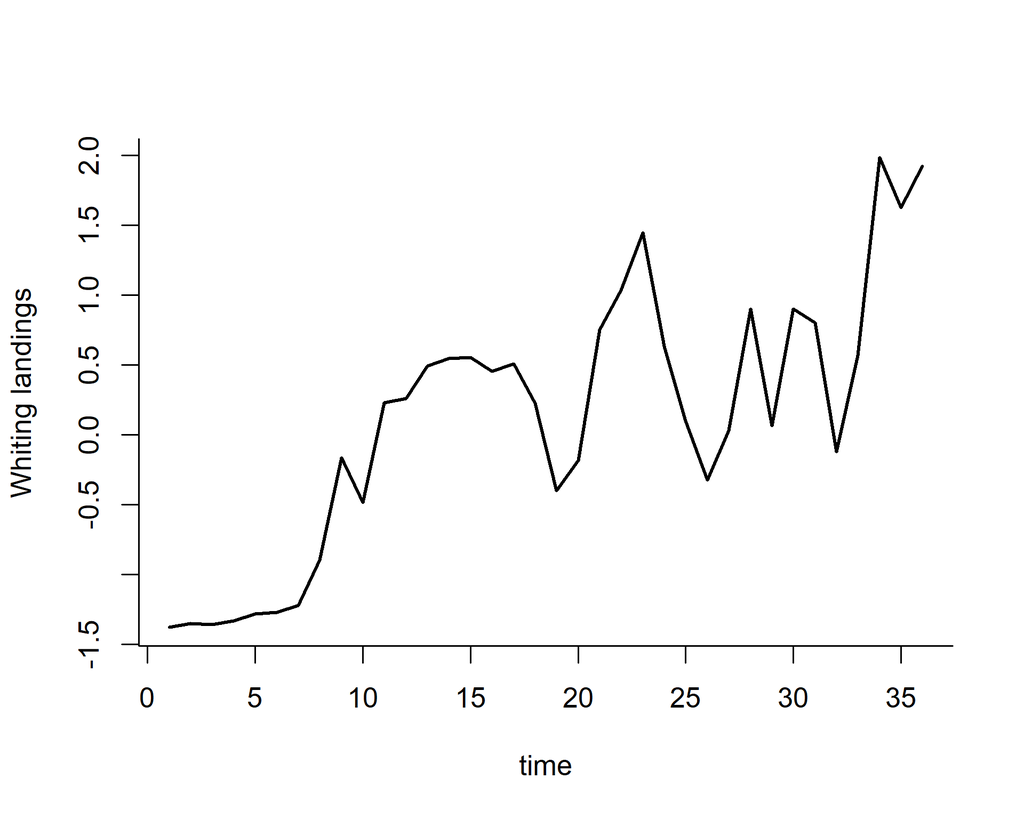

```r
with(model_dat, plot(time, p_whiting, 'l', bty = 'L', lwd = 2, ylab = 'Whiting landings'))
```

Split into 75% train and 25% test periods

```r
data_train <- model_dat[1:27,]
data_test <- model_dat[28:36,]
```

Fit an `mgcv` autocorrelated observation model, with an additional TPRS smooth function of time and a TRPS smooth function of whiting landings

```r
m_mgcv <- gam(y ~ s(p_whiting, k = 5) +
                s(time, k = 12) +
                lag1 + lag2 + lag3,
              data = data_train,
              method = "REML", family = nb())
summary(m_mgcv)
```

```
##
## Family: Negative Binomial(8.18)
## Link function: log
##
## Formula:
## y ~ s(p_whiting, k = 5) + s(time, k = 12) + lag1 + lag2 + lag3
##
## Parametric coefficients:
##             Estimate Std. Error z value Pr(>|z|)
## (Intercept)   1.8207     1.0265   1.774   0.0761 .
## lag1          0.7439     0.1870   3.978 6.96e-05 ***
## lag2          0.2532     0.2264   1.118   0.2634
## lag3         -0.2731     0.1912  -1.429   0.1530
## ---
## Signif. codes:  0 '***' 0.001 '**' 0.01 '*' 0.05 '.' 0.1 ' ' 1
##
## Approximate significance of smooth terms:
##              edf Ref.df Chi.sq p-value
## s(p_whiting)   1      1  0.046   0.831
## s(time)        1      1  1.842   0.175
##
## R-sq.(adj) =  0.817   Deviance explained = 92.2%
## -REML = 194.17  Scale est. = 1         n = 27
```

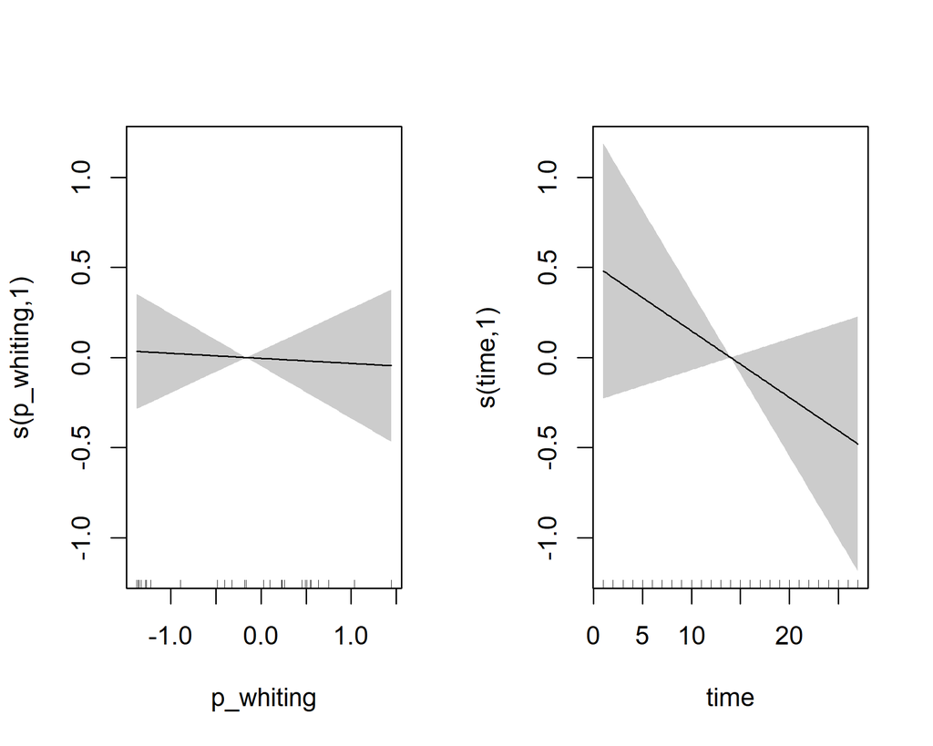

```r
plot(m_mgcv, pages=1, shade = TRUE)
```

```r
coef_sim <- gam.mh(m_mgcv)$bs

# Forecast 9 years ahead
gam_sims <- matrix(NA, nrow = 1000, ncol = 9)
for(i in 1:1000){
  gam_sims[i,] <- recurse_ar3(m_mgcv,
                              coef_sim,
                              lagged_vals = c(data_test$lag1[1],
                                              data_test$lag2[1],
                                              data_test$lag3[1]),
                              log_lags = TRUE,
                              h = 9)
}
```

Now fit an `mvgam` model where the latent trend is modelled as an `AR3` process. We will use `Stan` for this example, which generally explores the joint posterior much more efficiently (and more fully) than `JAGS`

```r
m_mvgam <- mvgam(y ~ s(p_whiting, k = 5),
                 data = data_train,
                 newdata = data_test,
                 family = 'nb',
                 trend_model = 'AR3',
                 use_stan = TRUE,
                 chains = 4,
                 burnin = 500)
```

```
## Running MCMC with 4 parallel chains...
##
## Chain 1 Iteration:   1 / 1000 [  0%]  (Warmup)
## Chain 2 Iteration:   1 / 1000 [  0%]  (Warmup)
## Chain 3 Iteration:   1 / 1000 [  0%]  (Warmup)
## Chain 4 Iteration:   1 / 1000 [  0%]  (Warmup)
## Chain 3 Iteration: 100 / 1000 [ 10%]  (Warmup)
## Chain 1 Iteration: 100 / 1000 [ 10%]  (Warmup)
## Chain 2 Iteration: 100 / 1000 [ 10%]  (Warmup)
## Chain 4 Iteration: 100 / 1000 [ 10%]  (Warmup)
## Chain 3 Iteration: 200 / 1000 [ 20%]  (Warmup)
## Chain 2 Iteration: 200 / 1000 [ 20%]  (Warmup)
## Chain 4 Iteration: 200 / 1000 [ 20%]  (Warmup)
## Chain 1 Iteration: 200 / 1000 [ 20%]  (Warmup)
## Chain 3 Iteration: 300 / 1000 [ 30%]  (Warmup)
## Chain 2 Iteration: 300 / 1000 [ 30%]  (Warmup)
## Chain 4 Iteration: 300 / 1000 [ 30%]  (Warmup)
## Chain 1 Iteration: 300 / 1000 [ 30%]  (Warmup)
## Chain 2 Iteration: 400 / 1000 [ 40%]  (Warmup)
## Chain 3 Iteration: 400 / 1000 [ 40%]  (Warmup)
## Chain 1 Iteration: 400 / 1000 [ 40%]  (Warmup)
## Chain 4 Iteration: 400 / 1000 [ 40%]  (Warmup)
## Chain 2 Iteration: 500 / 1000 [ 50%]  (Warmup)
## Chain 3 Iteration: 500 / 1000 [ 50%]  (Warmup)
## Chain 1 Iteration: 500 / 1000 [ 50%]  (Warmup)
## Chain 2 Iteration: 501 / 1000 [ 50%]  (Sampling)
## Chain 3 Iteration: 501 / 1000 [ 50%]  (Sampling)
## Chain 4 Iteration: 500 / 1000 [ 50%]  (Warmup)
## Chain 1 Iteration: 501 / 1000 [ 50%]  (Sampling)
## Chain 4 Iteration: 501 / 1000 [ 50%]  (Sampling)
## Chain 2 Iteration: 600 / 1000 [ 60%]  (Sampling)
## Chain 3 Iteration: 600 / 1000 [ 60%]  (Sampling)
## Chain 4 Iteration: 600 / 1000 [ 60%]  (Sampling)
## Chain 1 Iteration: 600 / 1000 [ 60%]  (Sampling)
## Chain 2 Iteration: 700 / 1000 [ 70%]  (Sampling)
## Chain 3 Iteration: 700 / 1000 [ 70%]  (Sampling)
## Chain 3 Iteration: 800 / 1000 [ 80%]  (Sampling)
## Chain 4 Iteration: 700 / 1000 [ 70%]  (Sampling)
## Chain 1 Iteration: 700 / 1000 [ 70%]  (Sampling)
## Chain 3 Iteration: 900 / 1000 [ 90%]  (Sampling)
## Chain 2 Iteration: 800 / 1000 [ 80%]  (Sampling)
## Chain 3 Iteration: 1000 / 1000 [100%]  (Sampling)
## Chain 3 finished in 3.1 seconds.
## Chain 4 Iteration: 800 / 1000 [ 80%]  (Sampling)
## Chain 1 Iteration: 800 / 1000 [ 80%]  (Sampling)
## Chain 2 Iteration: 900 / 1000 [ 90%]  (Sampling)
## Chain 4 Iteration: 900 / 1000 [ 90%]  (Sampling)
## Chain 1 Iteration: 900 / 1000 [ 90%]  (Sampling)
## Chain 2 Iteration: 1000 / 1000 [100%]  (Sampling)
## Chain 2 finished in 3.6 seconds.
## Chain 1 Iteration: 1000 / 1000 [100%]  (Sampling)
## Chain 4 Iteration: 1000 / 1000 [100%]  (Sampling)
## Chain 1 finished in 3.8 seconds.
## Chain 4 finished in 3.8 seconds.
##
## All 4 chains finished successfully.
## Mean chain execution time: 3.6 seconds.
## Total execution time: 3.9 seconds.
```

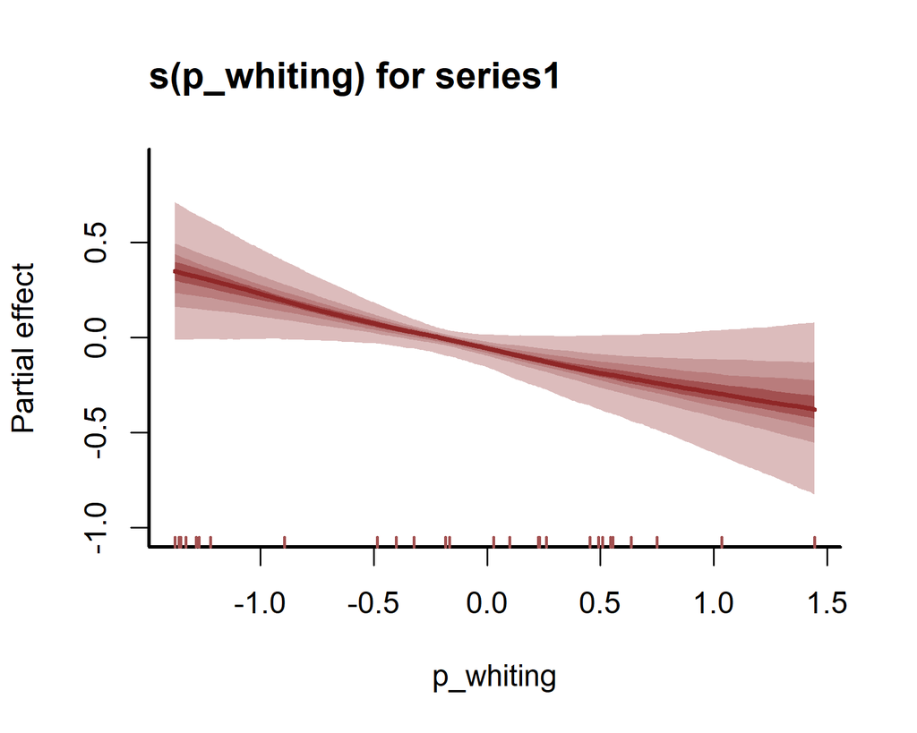

```r
plot(m_mvgam, 'smooths')
```

Inspect posterior realisations of the smooth function

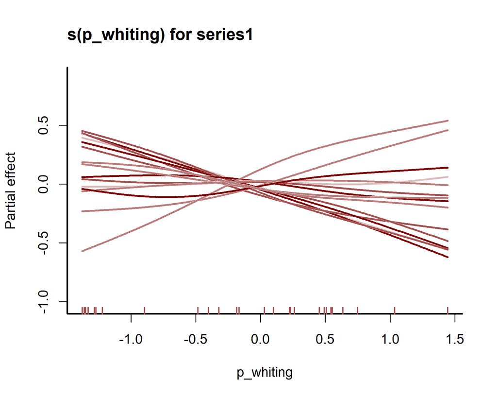

```r
plot(m_mvgam, 'smooths', realisations = TRUE)
```

The `plot_mvgam_smooth` function allows more flexibility for plotting smooth functions, including an ability to supply `newdata` for plotting posterior marginal simulations. Overlay the partial Dunn-Smyth residuals on the smooth plot for `p_whiting`. These residuals suggest there is still structure left in the data and that perhaps the smooth for this term is not as flexible as it could be (i.e. we would be justified to try this model again by increasing `k` for the smooth term). But we will leave it as-is for now

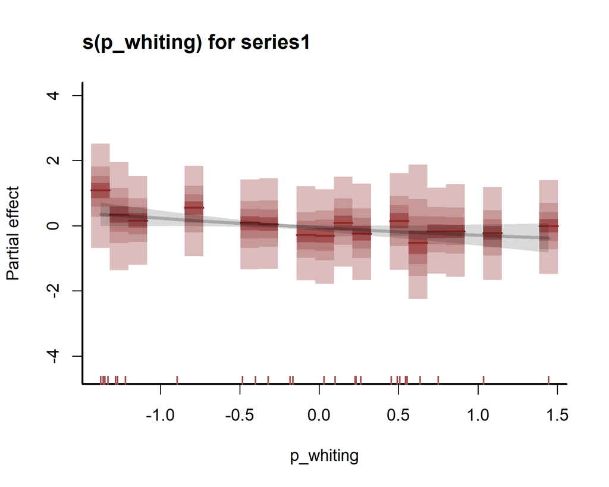

```r
plot_mvgam_smooth(m_mvgam, series = 1, smooth = 'p_whiting', residuals = TRUE)
```

We can also perform a series of posterior predictive checks (using the `ppc()` function) to see if the model is able to simulate data for the training period that looks realistic and unbiased. First, examine simulated histograms for posterior predictions (`yhat`) and compare to the observations (`y`)

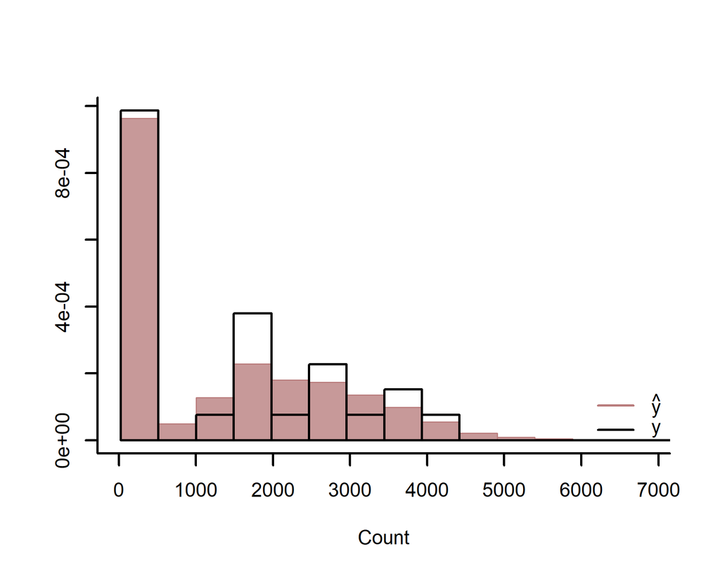

```r
ppc(m_mvgam, series = 1, type = 'hist', legend_position = 'bottomright')
```

Now plot the distribution of predicted means compared to the observed mean

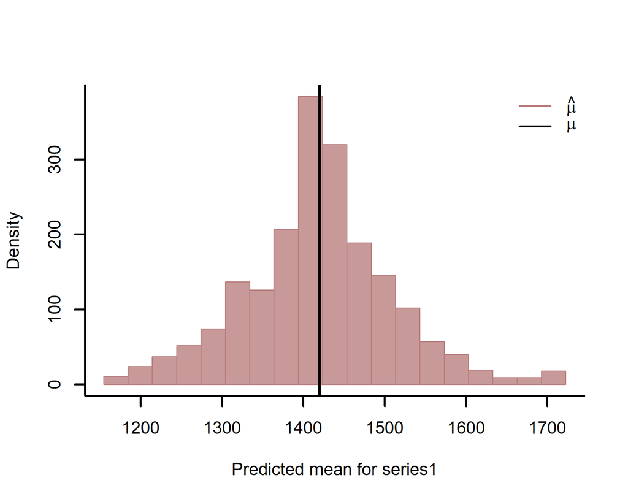

```r
ppc(m_mvgam, series = 1, type = 'mean')
```

Next examine simulated empirical Cumulative Distribution Functions (CDF) for posterior predictions (`yhat`) and compare to the CDF of the observations (`y`)

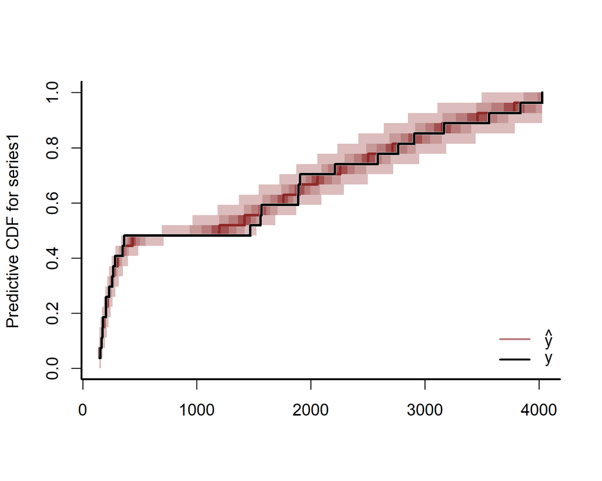

```r
ppc(m_mvgam, series = 1, type = 'cdf')
```

Finally look for any biases in predictions by examining a Probability Integral Transform (PIT) histogram. If our predictions are not biased one way or another (i.e. not consistently under- or over-predicting), this histogram should look roughly uniform

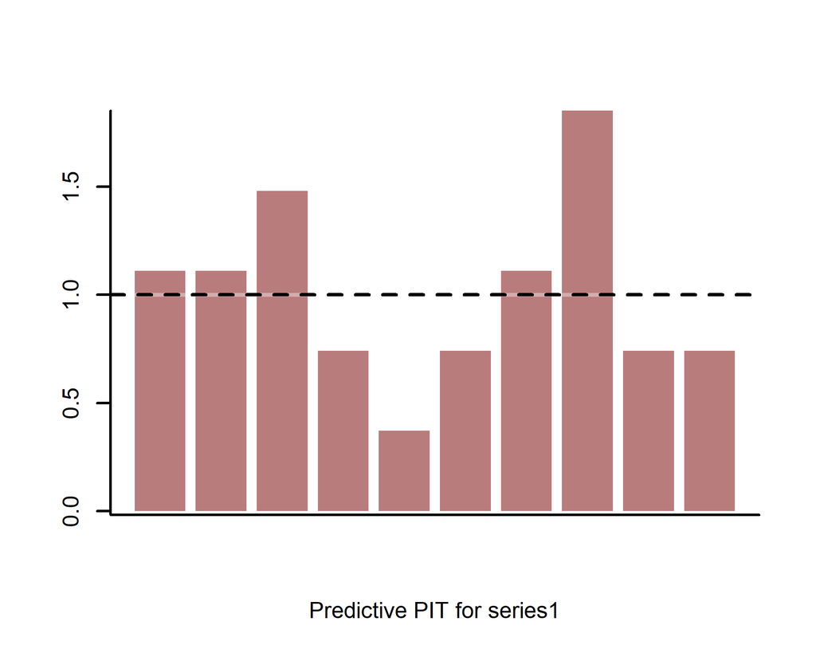

```r
ppc(m_mvgam, series = 1, type = 'pit')
```

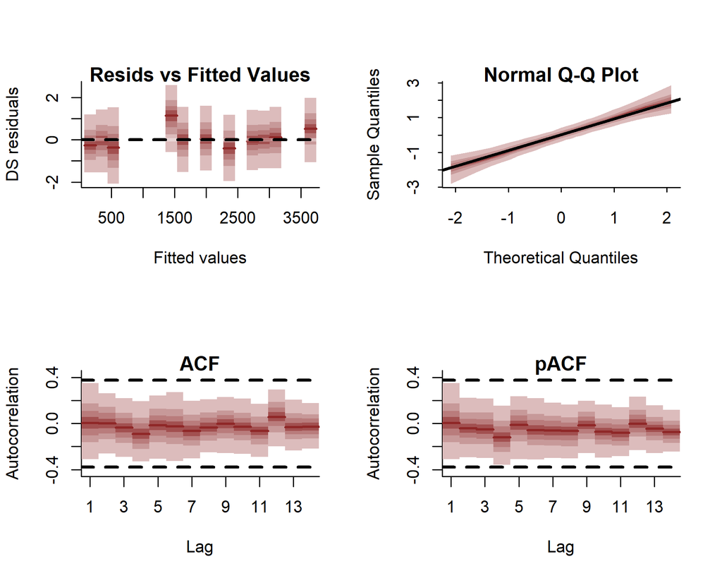

```r
plot(m_mvgam, series = 1, type = 'residuals')
```

Ok so the model is doing well when fitting against the training data, but how are its forecasts? We can now evaluate the forecasts of the two competing models just as we did above for the simulated data

```
## Out of sample DRPS:
```

```
## [1] 3595.449
```

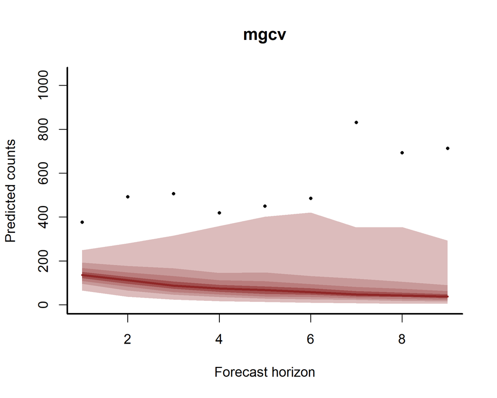

```r
plot_fc_horizon(gam_sims = gam_sims, main = 'mgcv')
```

```r
plot_fc_horizon(gam_sims = MCMCvis::MCMCchains(m_mvgam$model_output,
                                               'ypred')[,(NROW(m_mvgam$obs_data)+1):
                                                          (NROW(m_mvgam$obs_data)+9)],
                main = 'mvgam')
```

[output not shown]

```
## Out of sample DRPS:
```

```
## [1] 2067.32
```

Both models fail to anticipate the upward swing in landings following the end of the training data, but as with the simulations above, the autocorrelated observation model fitted by `mgcv` is providing inferior forecasts compared to the dynamic trend model estimated by `mvgam`. What if we try to improve the smooth function of time to do improve the forecasts? To try and capture the long-term trend we can use a `B` spline with multiple penalties, following the excellent example by Gavin Simpson about [extrapolating with smooth terms](https://fromthebottomoftheheap.net/2020/06/03/extrapolating-with-gams/). This is similar to what we might do when trying to forecast ahead from a more wiggly function, as `B` splines have useful properties by allowing the penalty to be extended into the range of values we wish to predict (in this case, the years in `data_test`).

```r
m_mgcv <- gam(y ~ s(p_whiting, k = 5) +
                s(time, bs = "bs", m = c(2, 1)) +
                lag1 + lag2 + lag3,
              knots = list(time = c(min(data_train$time) - 1,
                                    min(data_train$time),
                                    max(data_train$time),
                                    max(data_test$time))),
              data = data_train,
              method = "REML", family = nb())
```

Forecast and evaluate against the dynamic GAM

```r
coef_sim <- gam.mh(m_mgcv)$bs
gam_sims <- matrix(NA, nrow = 1000, ncol = 9)
for(i in 1:1000){
  gam_sims[i,] <- recurse_ar3(m_mgcv,
                              coef_sim,
                              lagged_vals = c(data_test$lag1[1],
                                              data_test$lag2[1],
                                              data_test$lag3[1]),
                              log_lags = TRUE,
                              h = 9)
}
```

```
## Out of sample DRPS:
```

```
## [1] 2530.831
```

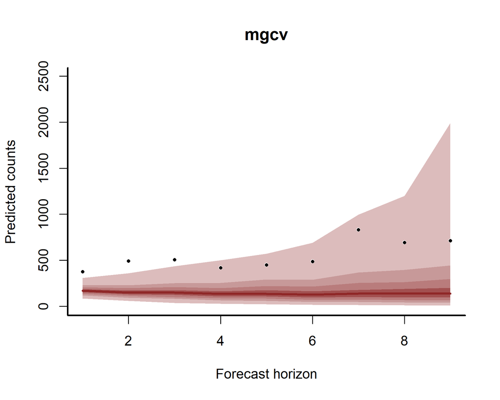

```r
plot_fc_horizon(gam_sims = gam_sims, main = 'mgcv')
```

```r
plot_fc_horizon(gam_sims = MCMCvis::MCMCchains(m_mvgam$model_output,
                                               'ypred')[,(NROW(m_mvgam$obs_data)+1):
                                                          (NROW(m_mvgam$obs_data)+9)],
                main = 'mvgam')
```

[output not shown]

```
## Out of sample DRPS:
```

```
## [1] 2067.32
```

This model shows an improvement in forecasting ability as the uncertainty in the temporal smooth function is more realistically growing into the future. But again, the dynamic GAM is superior in forecasting ability. Perhaps the `AR` terms are doing more harm than good for the model’s forecasts? For a final comparison, drop the `AR` functions

```r
m_mgcv <- gam(y ~ s(p_whiting, k = 5) +
                s(time, bs = "bs", m = c(2, 1), k = 15),
              knots = list(time = c(min(data_train$time) - 1,
                                    min(data_train$time),
                                    max(data_train$time),
                                    max(data_test$time))),
              data = data_train,
              method = "REML", family = nb())
```

```r
coef_sim <- gam.mh(m_mgcv)$bs
gam_sims <- matrix(NA, nrow = 1000, ncol = 9)
for(i in 1:1000){
  gam_sims[i,] <- recurse_ar3(m_mgcv,
                              coef_sim,
                              lagged_vals = c(data_test$lag1[1],
                                              data_test$lag2[1],
                                              data_test$lag3[1]),
                              log_lags = TRUE,
                              h = 9)
}
```

```
## Out of sample DRPS:
```

```
## [1] 2807.138
```

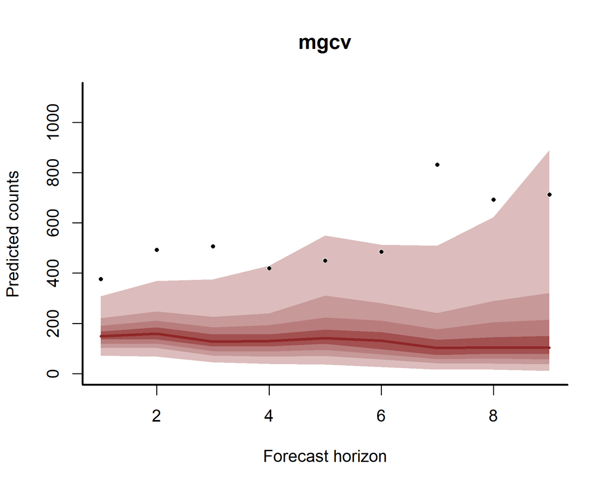

```r
plot_fc_horizon(gam_sims = gam_sims, main = 'mgcv')
```

```r
plot_fc_horizon(gam_sims = MCMCvis::MCMCchains(m_mvgam$model_output,
                                               'ypred')[,(NROW(m_mvgam$obs_data)+1):
                                                          (NROW(m_mvgam$obs_data)+9)],
                main = 'mvgam')
```

[output not shown]

```
## Out of sample DRPS:
```

```
## [1] 2067.32
```

The dynamic GAM is difficult to beat for this example. But what other utilities does the `mvgam` package make available? We can also re-do the posterior predictive checks, but this time focusing only on the out of sample period. This will give us better insight into how the model is performing and whether it is able to simulate realistic and unbiased future values

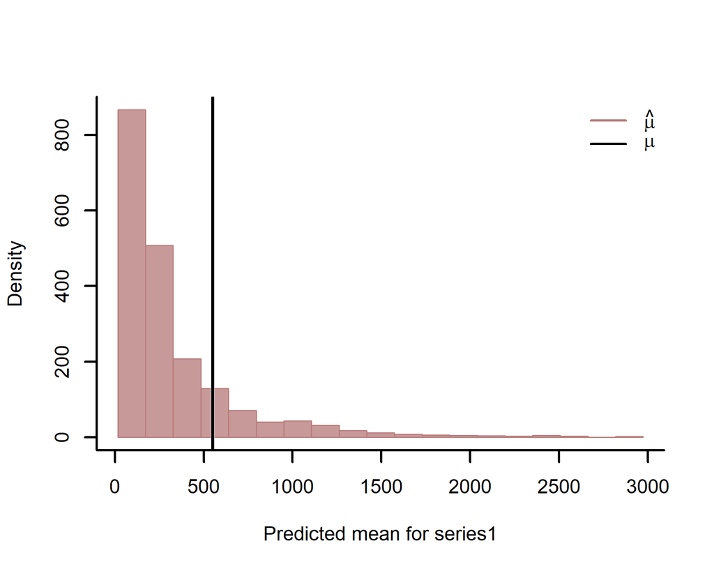

```r
ppc(m_mvgam, series = 1, type = 'mean', newdata = data_test)
```

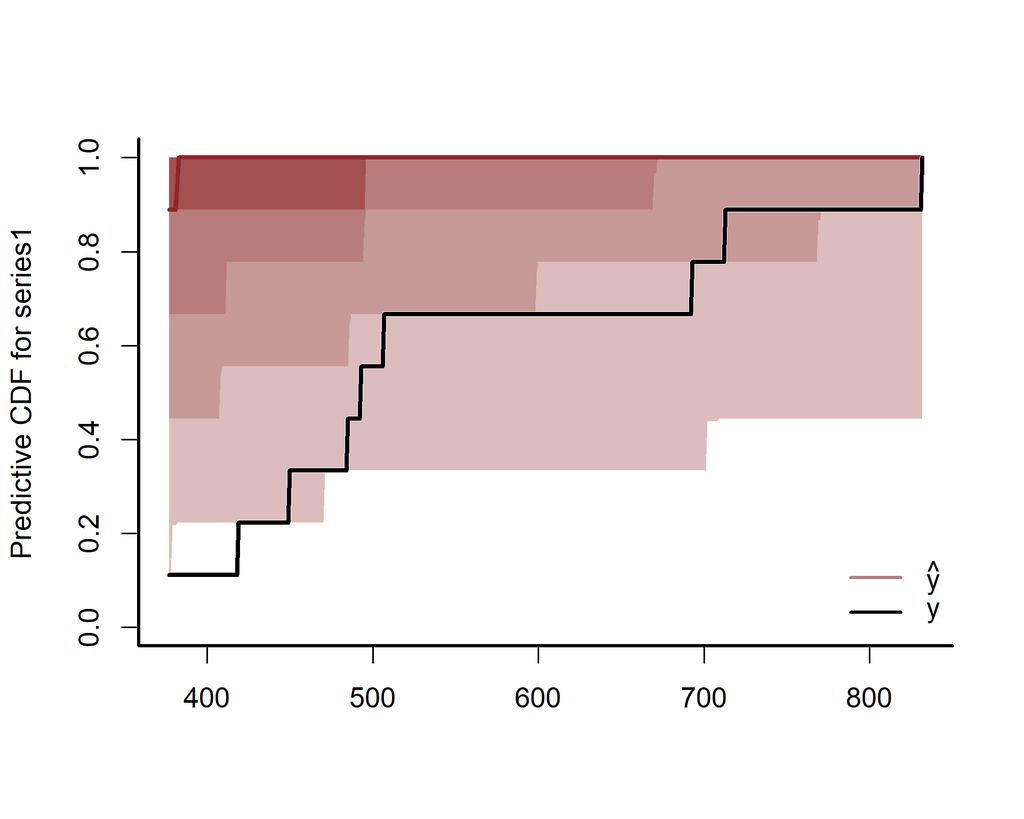

```r
ppc(m_mvgam, series = 1, type = 'cdf', newdata = data_test)
```